# groupADA

AmaliaS.

2024-03-17

```r
# import loan data as df
df <- read_excel("loan_data_ADA_assignment.xlsx")
```

```r
summary(df)
```

```
##        id            member_id         loan_amnt      funded_amnt
##  Min.   :  58524   Min.   : 149512   Min.   : 1000   Min.   : 1000
##  1st Qu.:1443048   1st Qu.:1695278   1st Qu.: 8000   1st Qu.: 8000
##  Median :1587758   Median :1857296   Median :12000   Median :12000
##  Mean   :1918444   Mean   :2283786   Mean   :13901   Mean   :13896
##  3rd Qu.:2311939   3rd Qu.:2744578   3rd Qu.:19200   3rd Qu.:19200
##  Max.   :3304574   Max.   :4076727   Max.   :35000   Max.   :35000
##
##  funded_amnt_inv      term          int_rate      installment
##  Min.   :  950   Min.   :36.00   Min.   : 6.00   Min.   :  25.81
##  1st Qu.: 7950   1st Qu.:36.00   1st Qu.:11.14   1st Qu.: 255.66
##  Median :12000   Median :36.00   Median :14.09   Median : 399.26
##  Mean   :13878   Mean   :40.49   Mean   :14.00   Mean   : 436.95
##  3rd Qu.:19175   3rd Qu.:36.00   3rd Qu.:17.27   3rd Qu.: 567.04
##  Max.   :35000   Max.   :60.00   Max.   :24.89   Max.   :1388.45
##
##     grade            sub_grade          emp_title           emp_length
##  Length:50000       Length:50000       Length:50000       Min.   : 1.000
##  Class :character   Class :character   Class :character   1st Qu.: 3.000
##  Mode  :character   Mode  :character   Mode  :character   Median : 6.000
##                                                           Mean   : 5.993
##                                                           3rd Qu.:10.000
##                                                           Max.   :10.000
##                                                           NA's   :1802
##  home_ownership       annual_inc      verification_status
##  Length:50000       Min.   :   5000   Length:50000
##  Class :character   1st Qu.:  45000   Class :character
##  Mode  :character   Median :  60000   Mode  :character
##                     Mean   :  71317
##                     3rd Qu.:  85000
##                     Max.   :7141778
##
##     issue_d                       loan_status         pymnt_plan
##  Min.   :2012-05-01 00:00:00.00   Length:50000       Length:50000
##  1st Qu.:2012-08-01 00:00:00.00   Class :character   Class :character
##  Median :2012-10-01 00:00:00.00   Mode  :character   Mode  :character
##  Mean   :2012-09-29 03:53:13.33
##  3rd Qu.:2012-12-01 00:00:00.00
##  Max.   :2013-02-01 00:00:00.00
##
```

[output cut: 73 more lines]

```
##  Min.   :0.00000   Min.   :    0   Min.   :      0   Min.   :      0
##  1st Qu.:0.00000   1st Qu.:    0   1st Qu.:  26298   1st Qu.:  14000
##  Median :0.00000   Median :    0   Median :  72117   Median :  22800
##  Mean   :0.00082   Mean   :   52   Mean   : 133594   Mean   :  29300
##  3rd Qu.:0.00000   3rd Qu.:    0   3rd Qu.: 202362   3rd Qu.:  36600
##  Max.   :4.00000   Max.   :55009   Max.   :8000078   Max.   :2013133
##                    NA's   :14618   NA's   :14618     NA's   :14618
##  loan_is_bad
##  Mode :logical
##  FALSE:42186
##  TRUE :7814
##
##
##
##
```

## **1. Define the Problem**

### **1.1. Objective**

- Utilising cluster analysisrouping borrowers with similar characteristics
- Identify distinct borrower’s segments
- Enabling personalised loan products, targeted marketing strategies, and a better customer support process to serve the unique needs of each segment

### **1.2. Select cluster variables**

1. annual_inc: The self-reported annual income provided by the borrower during registration.
2. loan_amnt: The listed amount of the loan applied for by the borrower. If at some point in time, the credit department reduces the loan amount, then it will be reflected in this value.
3. int_rate: Interest Rate on the loan
4. total_rec_int: Interest received to date
5. total_rec_prncp: Principal received to date
6. dti: A ratio calculated using the borrower’s total monthly debt payments on the total debt obligations, excluding mortgage and the requested LC loan, divided by the borrower’s self-reported monthly income.
7. total_rec_late_fee: Late fees received to date
8. term : The entire period of the loan
9. home_ownership: The home ownership status provided by the borrower during registration or obtained from the credit report. Our values are: RENT, OWN, MORTGAGE, OTHER
10. grade : The grade of loan

```r
# create new df with essential variables (10 variables)
df_ess <- df %>% select(annual_inc,
                        loan_amnt,
                        int_rate,
                        total_rec_int,
                        total_rec_prncp,
                        dti,
                        total_rec_late_fee,
                        term,
                        home_ownership,
                        grade
                        )
```

## **2. Pre-Analysis Decision**

### **2.1. Data checking (duplicate, missing values, outliers)**

- Check duplicate value

```r
# total row of data
df_row <- nrow(df_ess)

# distinct data
unique_row <- nrow(distinct(df_ess))

# verification. No duplicated data
duplicated <- df_row - unique_row
print(duplicated)
```

```
## [1] 0
```

- Check missing value

```r
missing_counts <- numeric(length(df_ess))

for (col in names(df_ess)) {
  missing_counts[col] <- sum(is.na(df_ess[[col]]))
}

missing_counts
```

```
##
##                  0                  0                  0                  0
##
##                  0                  0                  0                  0
##                                               annual_inc          loan_amnt
##                  0                  0                  0                  0
##           int_rate      total_rec_int    total_rec_prncp                dti
##                  0                  0                  0                  0
## total_rec_late_fee               term     home_ownership              grade
##                  0                  0                  0                  0
```

No missing value in cluster variables.

- Outliers Graphical method

```r
knitr::opts_chunk$set(warning = FALSE, message = FALSE)

df_summary <- summarytools::dfSummary(df_ess)
filename <- "df_summary.html"
summarytools::view(df_summary, file = filename)
```

```
## Output file written: /cloud/project/df_summary.html
```

```r
summary(df_ess)
```

```
##    annual_inc        loan_amnt        int_rate     total_rec_int
##  Min.   :   5000   Min.   : 1000   Min.   : 6.00   Min.   :    0
##  1st Qu.:  45000   1st Qu.: 8000   1st Qu.:11.14   1st Qu.: 1058
##  Median :  60000   Median :12000   Median :14.09   Median : 2047
##  Mean   :  71317   Mean   :13901   Mean   :14.00   Mean   : 3071
##  3rd Qu.:  85000   3rd Qu.:19200   3rd Qu.:17.27   3rd Qu.: 3737
##  Max.   :7141778   Max.   :35000   Max.   :24.89   Max.   :22778
##  total_rec_prncp      dti        total_rec_late_fee      term
##  Min.   :    0   Min.   : 0.00   Min.   :  0.0000   Min.   :36.00
##  1st Qu.: 6000   1st Qu.:11.51   1st Qu.:  0.0000   1st Qu.:36.00
##  Median :10000   Median :17.16   Median :  0.0000   Median :36.00
##  Mean   :11611   Mean   :17.37   Mean   :  0.8419   Mean   :40.49
##  3rd Qu.:15479   3rd Qu.:23.05   3rd Qu.:  0.0000   3rd Qu.:36.00
##  Max.   :35000   Max.   :34.99   Max.   :286.7476   Max.   :60.00
##  home_ownership        grade
##  Length:50000       Length:50000
##  Class :character   Class :character
##  Mode  :character   Mode  :character
##
##
##
```

### **2.2. Data encoding**

1. Home-ownership: recode to metric variables - sequence order by financial stability (1-highest, 5-lowest)
1. OWN -1
2. MORTGAGE-2
3. RENT -3
4. OTHER-4
5. NONE-5
2. grade : 1 - 7 (A - G) 1: Highest (A) 7: Lowest (G)
3. Term: 0 -> 36 (short-term) 1 -> 60 (long-term)

```r
# Change into factor
df_ess$home_ownership <- as.factor(df_ess$home_ownership)
df_ess$grade <- as.factor(df_ess$grade)
df_ess$term <- as.factor(df_ess$term)

# Recode
df_ess$home_ownership <- plyr::revalue(df_ess$home_ownership,
                                       c('OWN' = 1, 'MORTGAGE' = 2, 'RENT' = 3, 'OTHER' = 4, 'NONE' = 5))


df_ess$grade <- plyr::revalue(df_ess$grade,
                             c('A' = 1, 'B' = 2, 'C' = 3, 'D' = 4, 'E' = 5, 'F' = 6, 'G' = 7))

df_ess$term <- plyr::revalue(df_ess$term,
                            c('36' = 0, '60' = 1))
```

```r
summary(df_ess)
```

```
##    annual_inc        loan_amnt        int_rate     total_rec_int
##  Min.   :   5000   Min.   : 1000   Min.   : 6.00   Min.   :    0
##  1st Qu.:  45000   1st Qu.: 8000   1st Qu.:11.14   1st Qu.: 1058
##  Median :  60000   Median :12000   Median :14.09   Median : 2047
##  Mean   :  71317   Mean   :13901   Mean   :14.00   Mean   : 3071
##  3rd Qu.:  85000   3rd Qu.:19200   3rd Qu.:17.27   3rd Qu.: 3737
##  Max.   :7141778   Max.   :35000   Max.   :24.89   Max.   :22778
##
##  total_rec_prncp      dti        total_rec_late_fee term      home_ownership
##  Min.   :    0   Min.   : 0.00   Min.   :  0.0000   0:40641   2:24784
##  1st Qu.: 6000   1st Qu.:11.51   1st Qu.:  0.0000   1: 9359   5:   42
##  Median :10000   Median :17.16   Median :  0.0000             4:   45
##  Mean   :11611   Mean   :17.37   Mean   :  0.8419             1: 3836
##  3rd Qu.:15479   3rd Qu.:23.05   3rd Qu.:  0.0000             3:21293
##  Max.   :35000   Max.   :34.99   Max.   :286.7476
##
##  grade
##  1: 8533
##  2:17859
##  3:12171
##  4: 7065
##  5: 2926
##  6: 1227
##  7:  219
```

```r
# Convert all selected columns to numeric
loanDataFiltered <- apply(df_ess, 2, as.numeric)
loanDataFiltered_df <- as.data.frame(loanDataFiltered)
summary(loanDataFiltered_df)
```

```
##    annual_inc        loan_amnt        int_rate     total_rec_int
##  Min.   :   5000   Min.   : 1000   Min.   : 6.00   Min.   :    0
##  1st Qu.:  45000   1st Qu.: 8000   1st Qu.:11.14   1st Qu.: 1058
##  Median :  60000   Median :12000   Median :14.09   Median : 2047
##  Mean   :  71317   Mean   :13901   Mean   :14.00   Mean   : 3071
##  3rd Qu.:  85000   3rd Qu.:19200   3rd Qu.:17.27   3rd Qu.: 3737
##  Max.   :7141778   Max.   :35000   Max.   :24.89   Max.   :22778
##  total_rec_prncp      dti        total_rec_late_fee      term
##  Min.   :    0   Min.   : 0.00   Min.   :  0.0000   Min.   :0.0000
##  1st Qu.: 6000   1st Qu.:11.51   1st Qu.:  0.0000   1st Qu.:0.0000
##  Median :10000   Median :17.16   Median :  0.0000   Median :0.0000
##  Mean   :11611   Mean   :17.37   Mean   :  0.8419   Mean   :0.1872
##  3rd Qu.:15479   3rd Qu.:23.05   3rd Qu.:  0.0000   3rd Qu.:0.0000
##  Max.   :35000   Max.   :34.99   Max.   :286.7476   Max.   :1.0000
##  home_ownership      grade
##  Min.   :1.000   Min.   :1.000
##  1st Qu.:2.000   1st Qu.:2.000
##  Median :2.000   Median :2.000
##  Mean   :2.353   Mean   :2.651
##  3rd Qu.:3.000   3rd Qu.:3.000
##  Max.   :5.000   Max.   :7.000
```

### **2.3. Sample size**

```r
set.seed(10)
sample <- sample_n(loanDataFiltered_df, 500)
```

## **3. Check Assumptions**

### **3.1. Representative**

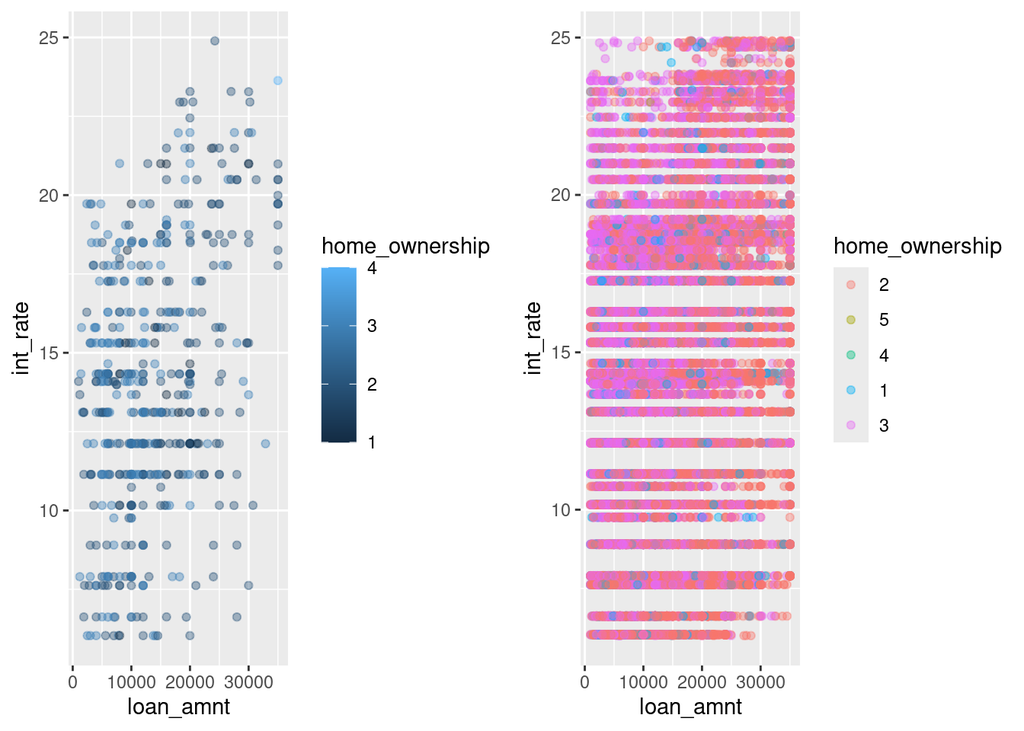

```r
# Sample distribution and Scatter plot
library("gridExtra")
gridExtra::grid.arrange(ggplot(sample, aes(x = loan_amnt, y = int_rate, color = home_ownership)) +
                          geom_point(position = "jitter", alpha = 0.4),
                        ggplot(df_ess, aes(x = loan_amnt, y = int_rate, color = home_ownership)) +
                          geom_point(position = "jitter", alpha = 0.4),
                        ncol = 2)
```

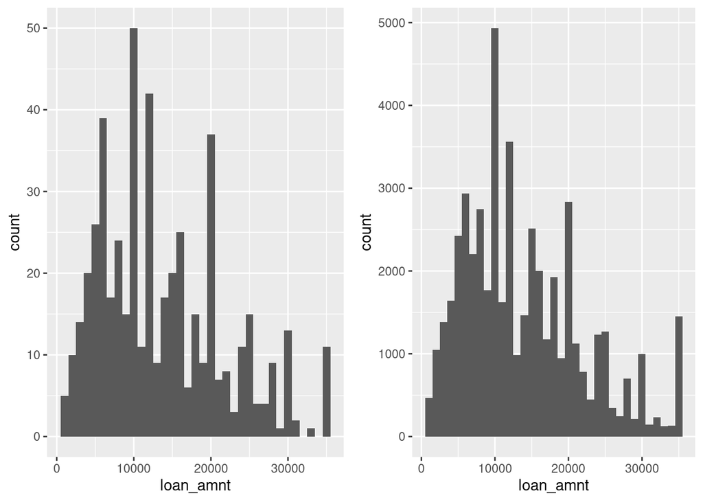

```r
gridExtra::grid.arrange(ggplot(sample, aes(x = loan_amnt)) + geom_histogram(binwidth = 1000),
                         ggplot(df_ess, aes(x = loan_amnt)) + geom_histogram(binwidth = 1000),
                         ncol = 2)
```

### **3.2. Multicollinearity: Correlation matrix**

```r
sampleMatrix<-cor(sample)
```

```r
round(sampleMatrix, 2)
```

```
##                    annual_inc loan_amnt int_rate total_rec_int total_rec_prncp
## annual_inc               1.00      0.29     0.06          0.27            0.20
## loan_amnt                0.29      1.00     0.37          0.76            0.81
## int_rate                 0.06      0.37     1.00          0.55            0.17
## total_rec_int            0.27      0.76     0.55          1.00            0.52
## total_rec_prncp          0.20      0.81     0.17          0.52            1.00
## dti                     -0.22      0.05     0.13          0.06            0.03
## total_rec_late_fee       0.02      0.10     0.03          0.09            0.11
## term                     0.15      0.50     0.49          0.60            0.22
## home_ownership          -0.07     -0.21    -0.01         -0.16           -0.20
## grade                    0.07      0.39     0.96          0.56            0.20
##                      dti total_rec_late_fee  term home_ownership grade
## annual_inc         -0.22               0.02  0.15          -0.07  0.07
## loan_amnt           0.05               0.10  0.50          -0.21  0.39
## int_rate            0.13               0.03  0.49          -0.01  0.96
## total_rec_int       0.06               0.09  0.60          -0.16  0.56
## total_rec_prncp     0.03               0.11  0.22          -0.20  0.20
## dti                 1.00               0.01  0.02           0.03  0.11
## total_rec_late_fee  0.01               1.00 -0.05           0.03  0.04
## term                0.02              -0.05  1.00          -0.15  0.51
## home_ownership      0.03               0.03 -0.15           1.00 -0.02
## grade               0.11               0.04  0.51          -0.02  1.00
```

```r
lowerCor(sample)
```

```
##                    annl_ ln_mn int_r ttl_rc_n ttl_rc_p dti   tt___ term  hm_wn
## annual_inc          1.00
## loan_amnt           0.29  1.00
## int_rate            0.06  0.37  1.00
## total_rec_int       0.27  0.76  0.55  1.00
## total_rec_prncp     0.20  0.81  0.17  0.52     1.00
## dti                -0.22  0.05  0.13  0.06     0.03     1.00
## total_rec_late_fee  0.02  0.10  0.03  0.09     0.11     0.01  1.00
## term                0.15  0.50  0.49  0.60     0.22     0.02 -0.05  1.00
## home_ownership     -0.07 -0.21 -0.01 -0.16    -0.20     0.03  0.03 -0.15  1.00
## grade               0.07  0.39  0.96  0.56     0.20     0.11  0.04  0.51 -0.02
##                    grade
## annual_inc
## loan_amnt
## int_rate
## total_rec_int
## total_rec_prncp
## dti
## total_rec_late_fee
## term
## home_ownership
## grade               1.00
```

### **3.3. Multicollinearity: Kaiser-Meyer-Olkin (KMO)**

```r
KMO(sample)
```

```
## Kaiser-Meyer-Olkin factor adequacy
## Call: KMO(r = sample)
## Overall MSA =  0.71
## MSA for each item =
##         annual_inc          loan_amnt           int_rate      total_rec_int
##               0.75               0.67               0.65               0.86
##    total_rec_prncp                dti total_rec_late_fee               term
##               0.61               0.55               0.60               0.83
##     home_ownership              grade
##               0.88               0.65
```

### **3.4. Multicollinearity: Bartlett’s test**

```r
cortest.bartlett(sample)
```

```
## $chisq
## [1] 2917.021
##
## $p.value
## [1] 0
##
## $df
## [1] 45
```

P-value is 0, which means there is a sufficient correlation between variables. We can use factor analysis in this case.

## **4. Perform Principal Component Analysis (PCA)**

```r
pcModel<-principal(sample, 5, rotate="none", weights=TRUE, scores=TRUE)
print(pcModel)
```

```
## Principal Components Analysis
## Call: principal(r = sample, nfactors = 5, rotate = "none", scores = TRUE,
##     weights = TRUE)
## Standardized loadings (pattern matrix) based upon correlation matrix
##                      PC1   PC2   PC3   PC4   PC5   h2    u2 com
## annual_inc          0.30 -0.46 -0.51  0.22  0.19 0.64 0.361 3.4
## loan_amnt           0.84 -0.39  0.19 -0.01  0.16 0.92 0.081 1.6
## int_rate            0.75  0.56 -0.14  0.08 -0.10 0.92 0.083 2.0
## total_rec_int       0.88 -0.09  0.01  0.02  0.05 0.79 0.212 1.0
## total_rec_prncp     0.63 -0.53  0.34  0.01  0.21 0.83 0.167 2.8
## dti                 0.09  0.37  0.72 -0.20  0.24 0.76 0.244 2.0
## total_rec_late_fee  0.09 -0.12  0.37  0.77 -0.47 0.98 0.025 2.3
## term                0.71  0.14 -0.19 -0.17 -0.06 0.60 0.402 1.4
## home_ownership     -0.22  0.36 -0.07  0.57  0.67 0.95 0.048 2.8
## grade               0.77  0.54 -0.14  0.08 -0.11 0.92 0.085 1.9
##
##                        PC1  PC2  PC3  PC4  PC5
## SS loadings           3.69 1.56 1.13 1.05 0.86
## Proportion Var        0.37 0.16 0.11 0.10 0.09
## Cumulative Var        0.37 0.53 0.64 0.74 0.83
## Proportion Explained  0.45 0.19 0.14 0.13 0.10
## Cumulative Proportion 0.45 0.63 0.77 0.90 1.00
##
## Mean item complexity =  2.1
## Test of the hypothesis that 5 components are sufficient.
##
## The root mean square of the residuals (RMSR) is  0.07
##  with the empirical chi square  236.16  with prob <  5.1e-49
##
## Fit based upon off diagonal values = 0.95
```

```r
print.psych(pcModel, cut=0.3, sort=TRUE)
```

```
## Principal Components Analysis
## Call: principal(r = sample, nfactors = 5, rotate = "none", scores = TRUE,
##     weights = TRUE)
## Standardized loadings (pattern matrix) based upon correlation matrix
##                    item   PC1   PC2   PC3   PC4   PC5   h2    u2 com
## total_rec_int         4  0.88                         0.79 0.212 1.0
## loan_amnt             2  0.84 -0.39                   0.92 0.081 1.6
## grade                10  0.77  0.54                   0.92 0.085 1.9
## int_rate              3  0.75  0.56                   0.92 0.083 2.0
## term                  8  0.71                         0.60 0.402 1.4
## total_rec_prncp       5  0.63 -0.53  0.34             0.83 0.167 2.8
## annual_inc            1       -0.46 -0.51             0.64 0.361 3.4
## dti                   6        0.37  0.72             0.76 0.244 2.0
## total_rec_late_fee    7              0.37  0.77 -0.47 0.98 0.025 2.3
## home_ownership        9        0.36        0.57  0.67 0.95 0.048 2.8
##
##                        PC1  PC2  PC3  PC4  PC5
## SS loadings           3.69 1.56 1.13 1.05 0.86
## Proportion Var        0.37 0.16 0.11 0.10 0.09
## Cumulative Var        0.37 0.53 0.64 0.74 0.83
## Proportion Explained  0.45 0.19 0.14 0.13 0.10
## Cumulative Proportion 0.45 0.63 0.77 0.90 1.00
##
## Mean item complexity =  2.1
## Test of the hypothesis that 5 components are sufficient.
##
## The root mean square of the residuals (RMSR) is  0.07
##  with the empirical chi square  236.16  with prob <  5.1e-49
##
## Fit based upon off diagonal values = 0.95
```

To produce the scree plot

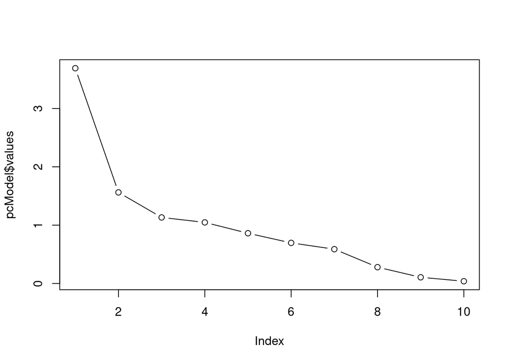

```r
plot(pcModel$values,type="b")
```

```r
pcModel$weights
```

```
##                            PC1         PC2         PC3          PC4         PC5
## annual_inc          0.08077978 -0.29386453 -0.44702185  0.211336565  0.21505306
## loan_amnt           0.22724608 -0.25017527  0.16852750 -0.012608901  0.19006420
## int_rate            0.20388818  0.35981820 -0.12090356  0.075981427 -0.11638677
## total_rec_int       0.23875150 -0.05686243  0.01128327  0.016732186  0.06257646
## total_rec_prncp     0.16944389 -0.34076013  0.30067456  0.005422551  0.24069513
## dti                 0.02405031  0.24000061  0.63163640 -0.192318501  0.27421682
## total_rec_late_fee  0.02435222 -0.07721672  0.32343541  0.735819109 -0.55046943
## term                0.19347312  0.08751756 -0.16911285 -0.164221480 -0.06470958
## home_ownership     -0.05908698  0.23224573 -0.05769586  0.541198712  0.77708951
## grade               0.20839761  0.34281299 -0.11965181  0.076032355 -0.13105886
```

We can then access these scores by using

```r
head(pcModel$scores, 10)
```

```
##              PC1        PC2        PC3         PC4        PC5
##  [1,] -0.9362977  0.5689859 -0.4954174  0.46310447  0.3189131
##  [2,] -0.4007959 -1.0803219 -0.1582872 -1.95481543 -1.9494720
##  [3,] -0.9696421 -1.4644904 -0.5948107  0.62450428  1.1336938
##  [4,] -0.3813357  0.5408023 -0.5210639  0.59892546  0.3624829
##  [5,] -0.4367595  0.5162278  1.1664280  0.03463419  1.3807775
##  [6,]  1.2747127 -1.3723158  1.0637235 -0.31856468  0.6282800
##  [7,] -0.2453597 -0.4118408  1.0225689  0.24853833  1.7307205
##  [8,] -0.6120398  0.3670978  0.9451526  0.10681232  1.1682691
##  [9,] -0.1046778 -0.2993457  0.6658561  0.38867458  1.5204344
## [10,] -0.6689182  1.3380139 -0.1416283  0.39483528  0.3665061
```

We can use the principal component scores for further analysis, before doing that we need to add them into our dataframe:

```r
sample_pca <- cbind(sample, pcModel$scores)
```

```r
summary(sample_pca)
```

```
##    annual_inc        loan_amnt        int_rate     total_rec_int
##  Min.   :  14000   Min.   : 1000   Min.   : 6.03   Min.   :   59.7
##  1st Qu.:  45000   1st Qu.: 7200   1st Qu.:11.14   1st Qu.:  998.4
##  Median :  60000   Median :12000   Median :14.09   Median : 1970.6
##  Mean   :  73102   Mean   :13662   Mean   :14.03   Mean   : 2982.6
##  3rd Qu.:  85000   3rd Qu.:19600   3rd Qu.:17.27   3rd Qu.: 3813.5
##  Max.   :1250000   Max.   :35000   Max.   :24.89   Max.   :17175.1
##  total_rec_prncp        dti        total_rec_late_fee      term
##  Min.   :  265.9   Min.   : 1.02   Min.   : 0.0000    Min.   :0.000
##  1st Qu.: 5971.4   1st Qu.:11.22   1st Qu.: 0.0000    1st Qu.:0.000
##  Median :10000.0   Median :16.48   Median : 0.0000    Median :0.000
##  Mean   :11545.0   Mean   :17.02   Mean   : 0.9973    Mean   :0.186
##  3rd Qu.:16000.0   3rd Qu.:23.02   3rd Qu.: 0.0000    3rd Qu.:0.000
##  Max.   :35000.0   Max.   :34.88   Max.   :64.3400    Max.   :1.000
##  home_ownership      grade            PC1               PC2
##  Min.   :1.000   Min.   :1.000   Min.   :-1.6576   Min.   :-4.815475
##  1st Qu.:2.000   1st Qu.:2.000   1st Qu.:-0.6791   1st Qu.:-0.638184
##  Median :2.000   Median :2.000   Median :-0.2757   Median : 0.002815
##  Mean   :2.368   Mean   :2.676   Mean   : 0.0000   Mean   : 0.000000
##  3rd Qu.:3.000   3rd Qu.:3.000   3rd Qu.: 0.4054   3rd Qu.: 0.741524
##  Max.   :4.000   Max.   :7.000   Max.   : 3.7382   Max.   : 2.345764
##       PC3                PC4               PC5
##  Min.   :-8.30745   Min.   :-1.9548   Min.   :-6.5452
##  1st Qu.:-0.60411   1st Qu.:-0.5538   1st Qu.:-0.5323
##  Median :-0.04166   Median :-0.1339   Median : 0.1074
##  Mean   : 0.00000   Mean   : 0.0000   Mean   : 0.0000
##  3rd Qu.: 0.56248   3rd Qu.: 0.4210   3rd Qu.: 0.6567
##  Max.   : 4.22046   Max.   : 7.6188   Max.   : 4.1670
```

## **5. Perform Factor Analysis**

```r
fa3v<-(fa(sample,2, n.obs=500, rotate="varimax", fm="pa"))
print.psych(fa3v, cut=0.3,sort="TRUE")
```

```
## Factor Analysis using method =  pa
## Call: fa(r = sample, nfactors = 2, n.obs = 500, rotate = "varimax",
##     fm = "pa")
## Standardized loadings (pattern matrix) based upon correlation matrix
##                    item  PA1   PA2     h2     u2 com
## int_rate              3 0.97       0.9538  0.046 1.0
## grade                10 0.95       0.9310  0.069 1.1
## term                  8 0.48  0.39 0.3831  0.617 1.9
## dti                   6            0.0178  0.982 1.1
## loan_amnt             2       1.00 1.0487 -0.049 1.1
## total_rec_prncp       5       0.75 0.5704  0.430 1.0
## total_rec_int         4 0.50  0.68 0.7128  0.287 1.8
## annual_inc            1       0.30 0.0925  0.908 1.0
## home_ownership        9            0.0587  0.941 1.0
## total_rec_late_fee    7            0.0087  0.991 1.0
##
##                        PA1  PA2
## SS loadings           2.41 2.37
## Proportion Var        0.24 0.24
## Cumulative Var        0.24 0.48
## Proportion Explained  0.50 0.50
## Cumulative Proportion 0.50 1.00
##
## Mean item complexity =  1.2
## Test of the hypothesis that 2 factors are sufficient.
##
## df null model =  45  with the objective function =  5.89 with Chi Square =  2917.02
## df of  the model are 26  and the objective function was  0.43
##
## The root mean square of the residuals (RMSR) is  0.05
## The df corrected root mean square of the residuals is  0.06
##
## The harmonic n.obs is  500 with the empirical chi square  100.75  with prob <  9.6e-11
## The total n.obs was  500  with Likelihood Chi Square =  211.73  with prob <  4.9e-31
##
## Tucker Lewis Index of factoring reliability =  0.888
## RMSEA index =  0.12  and the 90 % confidence intervals are  0.105 0.135
## BIC =  50.15
## Fit based upon off diagonal values = 0.98
```

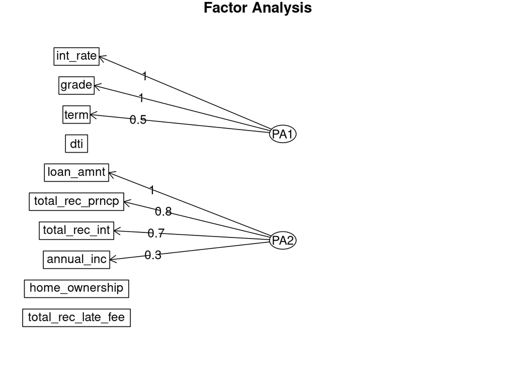

```r
fa.diagram(fa3v)
```

Once you have decided best solution, you can set scores to regression.

```r
fa3v<-(fa(sample,2, n.obs=500, rotate="varimax", fm="pa", scores="regression"))
head(fa3v$scores, 10)
```

```
##               PA1        PA2
##  [1,] -0.18085623 -1.1381673
##  [2,] -1.25971881 -0.3675690
##  [3,] -1.84634926  0.5655897
##  [4,]  0.19832737 -0.5813052
##  [5,] -0.73987157  1.5818343
##  [6,] -0.03012164  2.0481682
##  [7,] -0.90231757  0.5370203
##  [8,] -0.61937263 -0.1590261
##  [9,] -0.45304492  0.4046091
## [10,]  0.48182208 -1.4589098
```

We can use the factor scores for further analysis, before doing that we need to add them into our dataframe:

```r
sample_fa3 <- fa3v$scores
```

```r
summary(sample_fa3)
```

```
##       PA1               PA2
##  Min.   :-2.0672   Min.   :-1.9379
##  1st Qu.:-0.6513   1st Qu.:-0.8054
##  Median :-0.1008   Median :-0.1588
##  Mean   : 0.0000   Mean   : 0.0000
##  3rd Qu.: 0.6534   3rd Qu.: 0.7085
##  Max.   : 2.5941   Max.   : 3.4486
```

## **6. Create Clusters**

-Calculate Mahalanobis distance to identify potential outliers

```r
Maha <- mahalanobis(sample_fa3,colMeans(sample_fa3),cov(sample_fa3))
print(Maha)
```

```
##   [1]  1.21946651  1.76893161  3.79781870  0.34748304  2.83303931  3.83008512
##   [7]  1.09720383  0.42070566  0.35880919  2.17290401  1.56507137  0.69646243
##  [13]  2.22831844  0.78767703  0.14201948  0.64237348  6.90499530  0.53718818
##  [19]  0.66851094  2.74547127  3.38104781  2.22068385  0.67995193  3.26871207
##  [25]  0.99981795  8.22994128  0.86155731  1.06459604  3.81325108  5.29110075
##  [31]  2.13290921  0.79748175  2.74348804  0.67140551  1.17391081  0.44277377
##  [37]  0.91020327  1.86519664  1.07297432  4.78158580  1.10529920  0.64843672
##  [43]  3.36152591  0.37892273  0.69462615  1.12675008  0.78429982  1.81070544
##  [49]  0.06108999  4.17262606  1.59245448  0.62654182  2.55650395  1.21522633
##  [55]  2.18841127  2.19369577  0.03747881 10.28892851  4.88852058  0.54682769
##  [61]  2.62609252  0.07690858  1.70154992  0.38890132  1.28072001  3.07390707
##  [67]  0.28297130  1.15437488  4.62641059  0.29186031  0.07749343  0.17655685
##  [73]  1.77076598  0.39557181  0.35359030  0.22722764  4.39182766  0.09876337
##  [79]  3.69833252  0.46801519  1.53197159  2.16254442  0.31242414  0.41321794
##  [85]  0.76943310  1.63369041  2.37968500  1.38516528  0.67147711  1.36402110
```

[output cut: 69 more lines]

```r
MahaPvalue <-pchisq(Maha,df=10,lower.tail = FALSE)
# print(MahaPvalue)
print(sum(MahaPvalue<0.001)) # no outlier
```

```
## [1] 0
```

```r
SampleMatrix<-cor(sample_fa3)
```

```r
round(sample_fa3, 2)
```

```
##          PA1   PA2
##   [1,] -0.18 -1.14
##   [2,] -1.26 -0.37
##   [3,] -1.85  0.57
##   [4,]  0.20 -0.58
##   [5,] -0.74  1.58
##   [6,] -0.03  2.05
##   [7,] -0.90  0.54
##   [8,] -0.62 -0.16
##   [9,] -0.45  0.40
##  [10,]  0.48 -1.46
##  [11,]  1.19  0.34
##  [12,]  0.82 -0.03
##  [13,]  0.77 -1.34
##  [14,]  0.38 -0.84
```

[output cut: 486 more lines]

```r
lowerCor(sample_fa3)
```

```
##     PA1   PA2
## PA1  1.00
## PA2 -0.01  1.00
```

There is no substantial number of correlations > 0.3